# Set Up a Coding Agent on Your Computer

Hands-on · Day 0 · Setup for AI-enabled Research

Kristoffer Bjärkefur

Impact Analytics

1 October 2026

## Objective

- Make sure that you are assigned a GitHub Copilot license
- Install the extensions needed in VS Code to use the GitHub Copilot Agent
- Learn how to monitor spending limits
- Run a first interaction with the agent

## Request access to WB GitHub Copilot

Find all GitHub Copilot-related resources at the WB here: https://github.com/worldbank/ospo/blob/main/docs/copilot/README.md.

Requirements:

- Know your github username (hint: this is not your email address)
- Send an email, *including your GitHub username*, to dimeanalytics@worldbank.org or share in the `Questions` channel in Teams saying that you are requesting access to WB GitHub Copilot – move to the next slide while waiting for confirmation

## Install GitHub Copilot Extension

- Open VS Code’s Extensions view and search for “GitHub Copilot Chat”. In recent versions of VS Code, it comes pre-installed.
- If you see “Install” next to “GitHub Copilot Chat”, first try to update VS Code via **Help → Check for Updates**. If there is an available update, install it, and then search again.
- If “Install” appears even when VS Code is up to date, click the “Install” button.

[figure not shown]

## Log in to your GitHub account

VS Code features and extensions that use your GitHub account share the same GitHub authentication. You may already be signed in if you are already using a feature or extension that has GitHub authentication set up for you.

If not, follow these steps:

[figure not shown]

## Make sure VS Code picks up your WB GitHub Copilot License

- For this step, make sure that you have received confirmation that you have been assigned a license. The steps below will confirm whether you have a license.
- Click the GitHub Copilot icon in the status bar at the bottom of your VS Code window again
- Make sure it says `Copilot Business` and not `Copilot Free` or anything else at the top
- If you have multiple licenses and want to confirm you are using the one provided by the WB, go to https://github.com/settings/copilot/features

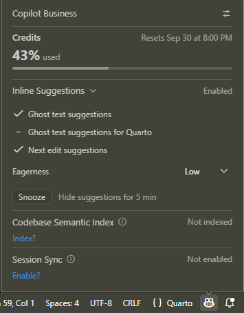

## Claude Code extension

If you want to use Claude Code in VS Code, then you need to follow similar steps.

1. Install the Claude Code extension in VS Code.
2. Log in with your personal Claude license - ITS currently do not provide WB-managed Claude licenses.

Note that, just like ChatGPT, we are not allowed to share non-public data with Claude. Making a request in Claude Code’s VS Code extension makes all files currently open in the VS Code workspace available to Claude. Any `.gitignore` file does not make a difference to this.

## Make your first interaction with GitHub Copilot

- Open a folder in VS Code with a project that you are familiar with. Preferably, choose one with a code folder, but this is not required.
- Open the chat by clicking the GitHub Copilot Chat icon next to the search bar at the top of your VS Code window.
- This is a common way to start an interaction with the agent, but there are other ways as well.

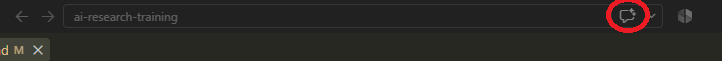

## Ask a question

To make sure the agent will not edit any files, switch the mode from “Agent” to “Ask”.

We will cover what these options mean in more detail next week.

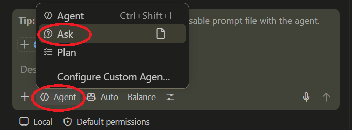

- Then ask the agent a question about your project.
- Since this is a coding agent, it is especially useful for code-related queries, but it can handle questions about other files as well.
- If you have a code folder, ask it to find the folder and give a high-level overview of what the code files in the project are about.
- Try other questions as well.